# PML Course Project: Predicting Good Weightlifting Form

Chelsea Heaven

22 November, 2015

# Introduction

The purpose of this analysis is to see if we can predict good weightlifting form by looking at biomarker data at various points during the weightlifting exercise. The data provided for this project comes from the [Weight Lifting Exercises (WLE) dataset](http://groupware.les.inf.puc-rio.br/work.jsf?p1=11201) (Ugulino, Cardador, Vega, Velloso, Milidiú, and Fuks, 2012)

The WLE dataset is comprised of 155 biomarker variables that were recorded as 6 participants forms 10 reps of a bicep curl with 5 different weightlifting forms. The weightlifting methdologies were:

- A: Exercise Preformed Exactly to Specification
- B: Throwing Elbows in the Front
- C: Lifting Dumbell Only Halfway
- D: Lowering The Dumbell Only Halfway
- E: Throwing Hips to the Front

For every participant, the weightlifting form for each biomarker position for each rep is noted in the **classe** variable. Thus, we would like to build a model to see if we can predict the **classe** variable for a test dataset of biomarker data of participants at varying positions. Sensors for the biomarkers were placed on the arm, forearm, belt, and dumbell.

# Building The Model

[output not shown]

## Variable Selection

The original training dataset was split into a training and test set using the **createDataPartition** function with a 75/25 split between training and test set. The newly created test set was used to analyze the possibility of narrowing down the 160 variables. The following criteria was used to exclude variables.

- A variable was removed if it had more than 85% missing values. A total of 103 variables were excluded by this criteria. Due to the extensive nature of the missing data imputations would have questionable validity. In addition, the excluded columns appear to be summary columns of each measurement. Therefore, leaving them in the model would be redundant.
- If a variable had something to do with an ID, timestamp, or a window, it was excluded from the dataset because variables like this would have no practical predictive value on the form of weightlifting exercises. This excluded 4 variables.

The final variable count was 53.

## Model Selection

For this analysis I decided to use the Stochastic Gradient Boosting model with **method = gbm**. I chose this method because many of the predictor variables are skewed, which would make a model-based prediction method less interpretable because of the transformations involved. In addition, since the purpose of this analysis is to classify a type of weightlifting form by various biomarkers, a classification algorithm makes the most sense. An example of the skewedness of the predictors is here:

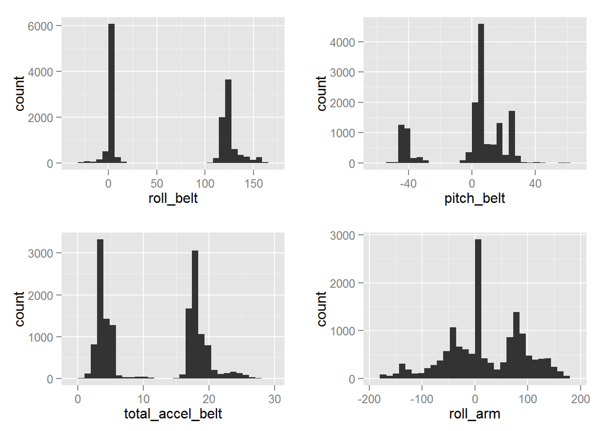

I chose the Stochastic Gradient Boosting model specifically because I was not geting good results from the basic Classification tree with **method=rpart**. The out of sample error using the basic Classification tree was 54%. This was not surprising given the typical distribution of the classe variable over various predictors was fairly close together. With the difference classes being so close together, a more sophisticated method was necessary.

Example of difficult classifications here with the roll_belt predictor

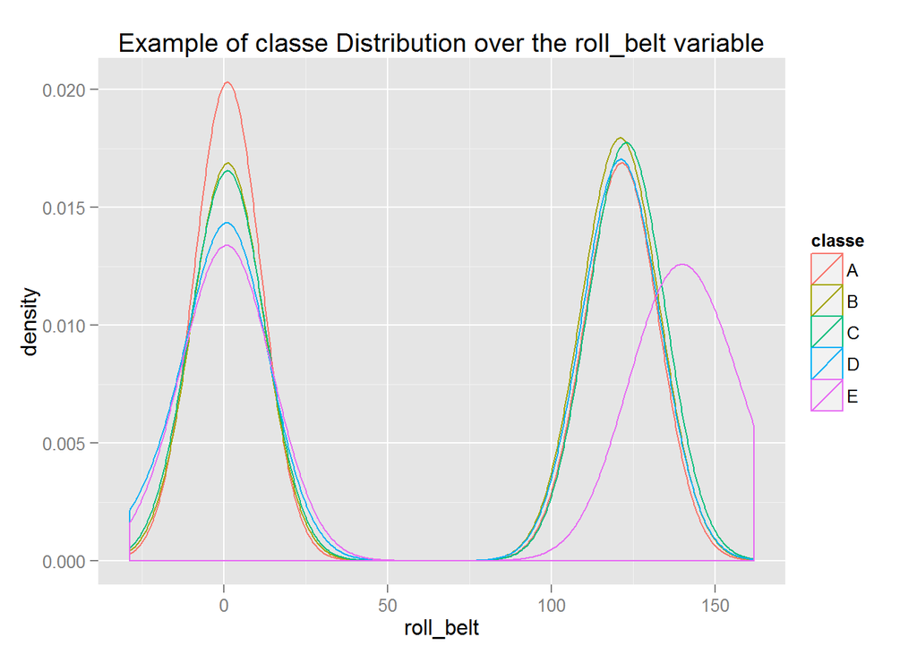

# Validating The Model

## Sample Error

Given the complexity of this data, these error rates are acceptable for the purpose of this analysis. While testing out various models these error rates were decreased with the inclusion of the timestamp variables, but since these timestamp variables do not have any relevance to the potential scaling of this data to participants doing weightlifting exercises in a different enviornment.

# Conclusion

The Stochastic Gradient Boosting model preformed well enough on the testing set for me to have confidence that it will predict the values for the assignment correctly. The **varImp** function identified the following variables as the top 5 most important to the prediction.

- roll_belt
- pitch_forearm
- yaw_belt
- magnet_dumbbell_z
- magnet_dumbbell_y

# References

Velloso, E.; Bulling, A.; Gellersen, H.; Ugulino, W.; Fuks, H. Qualitative Activity Recognition of Weight Lifting Exercises. Proceedings of 4th International Conference in Cooperation with SIGCHI (Augmented Human ’13) . Stuttgart, Germany: ACM SIGCHI, 2013.